# Heterogeneous Treatment Effects in a Crowdsourced Megastudy of Single-Session Interventions for Depression

Reproducible analysis

Published

June 30, 2026

# 1 Overview

Reproduces the secondary HTE analysis of a crowdsourced megastudy of single-session interventions (SSIs) for depression (N = 7,505; 12 SSIs vs. control). Run `Rscript R/01_generate_ipw_weights.R` first to produce `data/sl_weights.csv`, then render this document. Tables and figures are written to `output/`. See `README.md` for details.

# 2 Setup

```r
library(tidyverse)
library(grf)
library(mclust)
library(glmnet)
library(tidymodels)
library(emmeans)
library(broom)
library(boot)
library(corrplot)
library(reshape2)
library(ggrepel)
library(car)

# Serpentine sort + fold helper (self-contained; no external packages)
source(file.path("R", "sl_helpers.R"))

ssi_labels <- c(
  "5 Habits to Beat Depression", "AI-assisted Personalized Narrative",
  "Behavioral Activation", "Dialectical Behavioral Therapy Skills",
  "Inner Child Healing Walk", "Interactive Cognitive Reappraisal",
  "Mindful Acceptance", "Mindful Attention Skills", "Moral Elevation",
  "Personalized Intervention Recommender", "Reframing Negative Thoughts",
  "Savoring Strategies"
)

# ---- Paths (relative to this document) ---------------------------------
DATA_DIR    <- "data"
TABLES_DIR  <- file.path("output", "tables")
FIGURES_DIR <- file.path("output", "figures")

dir.create(TABLES_DIR,  showWarnings = FALSE, recursive = TRUE)
dir.create(FIGURES_DIR, showWarnings = FALSE, recursive = TRUE)
```

# 3 Data load and cleaning

```r
mydata <- read.csv(file.path(DATA_DIR, "ml_clean.csv"), header = TRUE)
mydata <- mydata[, -1]  # drop leading row-number column
mydata <- mydata %>% select(-help_prefer_not_say_baseline)  # zero-variance

# Reverse-score PHQ-9 follow-up: higher = better, matches HTE convention
mydata$phq9_score_followup <- 27 - mydata$phq9_score_followup

# Build PHQ-9 baseline raw + reverse-scored versions
items_phq9_baseline    <- paste0("phq9_", 1:9, "_baseline")
mydata$phq9_pre_raw    <- rowSums(mydata[, items_phq9_baseline], na.rm = TRUE)
mydata$phq9_pre_rev    <- 27 - mydata$phq9_pre_raw

# Follow-up completion indicator
mydata$fup_complete <- as.integer(!is.na(mydata$phq9_score_followup))

# Intervention-vs-control indicator
mydata$int_binary <- ifelse(mydata$group_numeric == 13, 0, 1)

# Note: `group_numeric` is left as integer here so it joins cleanly with
# `sl_weights.csv` in the next chunk. It is converted to a factor
# (with control = 13 as reference) later, after the IPW merge.

cat("N randomized:", nrow(mydata), "\n")
```

```
N randomized: 7505
```

```r
cat("N completers (4-week PHQ-9):", sum(mydata$fup_complete), "\n")
```

```
N completers (4-week PHQ-9): 5957
```

## 3.1 Drop low-variance covariates

```r
# Baseline covariate columns (positions 4:102 in the cleaned file)
W_full <- mydata[, 4:102]

constant_vars <- sapply(W_full, function(x) length(unique(x)) <= 1)
low_variance  <- sapply(W_full, function(x) {
  if (is.numeric(x) && all(x %in% c(0, 1))) {
    min(sum(x == 0, na.rm = TRUE), sum(x == 1, na.rm = TRUE)) < 5
  } else {
    FALSE
  }
})

keep_cols <- !(constant_vars | low_variance)
cat("Dropped",  sum(!keep_cols), "low/zero-variance baseline covariates\n")
```

```
Dropped 2 low/zero-variance baseline covariates
```

```r
cat("Retained", sum(keep_cols), "baseline covariates for CATE estimation\n")
```

```
Retained 97 baseline covariates for CATE estimation
```

# 4 Attach loss-to-follow-up weights

Join the weights from step 1 onto `mydata` by `pid` × `group_numeric`.

```r
weights_path <- file.path(DATA_DIR, "sl_weights.csv")
if (!file.exists(weights_path)) {
  stop("data/sl_weights.csv not found. Run `Rscript R/01_generate_ipw_weights.R` first.")
}

weights_long <- read.csv(weights_path)
weights_to_merge <- weights_long %>%
  select(pid, intervention, w_norm) %>%
  distinct()

mydata <- mydata %>%
  left_join(weights_to_merge,
            by = c("pid", "group_numeric" = "intervention"))

stopifnot(sum(is.na(mydata$w_norm)) == 0)

# Now safe to convert `group_numeric` to a factor with control as reference.
mydata$group_numeric <- factor(mydata$group_numeric)
mydata$group_numeric <- relevel(mydata$group_numeric, ref = "13")
```

# 5 CATE estimation — Generalized Causal Forests with 10-fold CV

For each SSI, a CATE relative to control (arm 13) is estimated from `grf::causal_forest` fit on 10 training folds (`make_folds_serpentine()`). Focal-arm and control participants get out-of-fold predictions; everyone else gets the average of the 10 forests.

```r
df_cate <- {

  controls   <- mydata %>% filter(group_numeric == 13)
  controls_f <- make_folds_serpentine(controls, nfolds = 10, seed = 123)
  control_folds_map <- controls_f %>% select(pid, fold)

  arms <- 1:12
  n_participants <- nrow(mydata)
  pid_vec <- mydata$pid

  mat_cate <- matrix(NA_real_,
                     nrow = n_participants,
                     ncol = length(arms),
                     dimnames = list(NULL, sprintf("CATE_%d", arms)))

  X_all <- as.matrix(mydata[, 4:102])

  for (arm in arms) {
    message(sprintf("Arm %d vs 13 (10-fold CV)", arm))

    arm_dat <- mydata %>% filter(group_numeric == arm)
    arm_f   <- make_folds_serpentine(arm_dat, nfolds = 10, seed = 1000 + arm)
    arm_folds_map <- arm_f %>% select(pid, fold)

    analytic <- mydata %>%
      filter(group_numeric %in% c(13, arm)) %>%
      left_join(control_folds_map, by = "pid") %>%
      left_join(arm_folds_map,     by = "pid",
                suffix = c("_ctrl", "_arm")) %>%
      mutate(fold = ifelse(group_numeric == 13, fold_ctrl, fold_arm)) %>%
      select(-fold_ctrl, -fold_arm)

    analytic_obs <- analytic %>% filter(!is.na(phq9_score_followup))

    oof_tau <- rep(NA_real_, nrow(analytic_obs))
    forests <- vector("list", 10)

    for (k in 1:10) {
      train_k <- analytic_obs %>% filter(fold != k)
      test_k  <- analytic_obs %>% filter(fold == k)
      if (nrow(train_k) < 20 || nrow(test_k) < 1) next

      X_train  <- as.matrix(train_k[, 4:102])
      Y_train  <- as.numeric(train_k$phq9_score_followup)
      W_train  <- as.integer(train_k$group_numeric == arm)
      wt_train <- as.numeric(train_k$w_norm)

      set.seed(2000 + arm * 100 + k)
      cf_k <- grf::causal_forest(
        X_train, Y_train, W_train,
        sample.weights = wt_train,
        num.trees      = 4000
      )
      forests[[k]] <- cf_k

      X_test <- as.matrix(test_k[, 4:102])
      idx    <- which(analytic_obs$fold == k)
      oof_tau[idx] <- as.numeric(predict(cf_k, X_test)$predictions)
    }

    tau_arm_all <- rep(NA_real_, n_participants)
    tau_arm_all[match(analytic_obs$pid, mydata$pid)] <- oof_tau

    # Predict onto everyone NOT in controls or this arm using the saved forests.
    other_idx <- which(!(mydata$group_numeric %in% c(13, arm)))
    pred_mat  <- matrix(NA_real_, nrow = length(other_idx), ncol = 10)
    for (k in 1:10) {
      if (is.null(forests[[k]])) next
      pred_mat[, k] <- as.numeric(
        predict(forests[[k]], X_all[other_idx, , drop = FALSE])$predictions)
    }
    tau_arm_all[other_idx] <- rowMeans(pred_mat, na.rm = TRUE)

    # Backfill any remaining NAs (skipped folds, missing outcomes in arm/control)
    miss_idx <- which(is.na(tau_arm_all))
    if (length(miss_idx) > 0) {
      pred_mat_all <- matrix(NA_real_, nrow = length(miss_idx), ncol = 10)
      for (k in 1:10) {
        if (is.null(forests[[k]])) next
        pred_mat_all[, k] <- as.numeric(
          predict(forests[[k]], X_all[miss_idx, , drop = FALSE])$predictions)
      }
      tau_arm_all[miss_idx] <- rowMeans(pred_mat_all, na.rm = TRUE)
    }

    mat_cate[, arm] <- tau_arm_all
  }

  data.frame(pid = pid_vec, mat_cate)
}

stopifnot(sum(is.na(df_cate)) == 0)
head(df_cate)
```

|  | pid | CATE_1 | CATE_2 | CATE_3 | CATE_4 | CATE_5 | CATE_6 | CATE_7 | CATE_8 | CATE_9 | CATE_10 | CATE_11 | CATE_12 |
| --- | --- | --- | --- | --- | --- | --- | --- | --- | --- | --- | --- | --- | --- |
| 1 | 1 | -0.56238254 | 0.05423961 | -0.02356237 | 0.5009923 | -0.88370355 | 0.9798533 | 0.5864049 | 0.024697150 | -0.07523006 | 0.37792687 | 0.003356001 | 0.20659145 |
| 2 | 2 | -0.04530624 | 0.20885897 | 0.09623774 | 0.2825841 | -0.20683952 | 1.0045853 | 0.8432156 | 0.454648497 | 0.15506105 | 0.20445788 | -0.088036995 | 0.10377309 |
| 3 | 3 | 0.22675422 | 0.18524683 | -0.14270983 | 0.4498956 | -0.17294184 | 0.8374854 | 0.5079893 | 0.320642807 | 0.34912726 | 0.04165704 | 0.002062819 | -0.06173433 |
| 4 | 4 | -0.07948878 | 0.09131955 | 0.27747882 | 0.4502545 | -0.08256594 | 0.9413401 | 0.6583075 | 0.424999102 | -0.11031663 | 0.33974019 | 0.146020171 | -0.01479471 |
| 5 | 5 | 0.06112093 | 0.12793735 | 0.14297744 | 0.5538325 | -0.27666367 | 1.0246322 | 0.5889497 | -0.004544611 | 0.06251238 | 0.64763069 | 0.049690861 | 0.16824215 |
| 6 | 6 | 0.56596633 | 0.08747235 | 0.15811453 | 0.5041560 | -0.06358633 | 0.8501443 | 0.5626459 | 0.487816158 | 0.44565271 | 0.71436059 | 0.266356753 | -0.19769831 |

## 5.1 GCF calibration → Supplementary Table 2

Per arm, fit a causal forest on the focal-arm + control sample and run `grf::test_calibration` (mean- and differential-prediction coefficients).

```r
calibration_results <- {
  out <- data.frame()
  for (arm in 1:12) {
    analytic_obs <- mydata %>%
      filter(group_numeric %in% c(arm, 13),
             !is.na(phq9_score_followup))

    X_full  <- as.matrix(analytic_obs[, 4:102])
    Y_full  <- as.numeric(analytic_obs$phq9_score_followup)
    W_full  <- as.integer(analytic_obs$group_numeric == arm)
    wt_full <- as.numeric(analytic_obs$w_norm)

    set.seed(3000 + arm)
    cf_full <- grf::causal_forest(
      X_full, Y_full, W_full,
      sample.weights = wt_full,
      num.trees      = 4000
    )
    cal <- test_calibration(cf_full)

    out <- rbind(out, data.frame(
      arm      = arm,
      mean_est = cal[1, 1], mean_se = cal[1, 2], mean_p = cal[1, 4],
      diff_est = cal[2, 1], diff_se = cal[2, 2], diff_p = cal[2, 4]
    ))
  }
  out
}

calibration_results$SSI <- ssi_labels[calibration_results$arm]
cal_out <- calibration_results[, c("arm", "SSI", "mean_est", "mean_se", "mean_p",
                                    "diff_est", "diff_se", "diff_p")]
write.csv(cal_out,
          file.path(TABLES_DIR, "supp_table2_calibration.csv"),
          row.names = FALSE)
print(cal_out, digits = 3)
```

```
   arm                                   SSI mean_est mean_se  mean_p diff_est
1    1           5 Habits to Beat Depression    1.123   1.869 0.27406  -1.1600
2    2    AI-assisted Personalized Narrative    0.793   1.563 0.30596  -5.4883
3    3                 Behavioral Activation    0.985   2.952 0.36934  -3.0863
4    4 Dialectical Behavioral Therapy Skills    1.077   0.596 0.03548  -3.1943
5    5              Inner Child Healing Walk    0.927   4.109 0.41079  -0.4627
6    6     Interactive Cognitive Reappraisal    0.994   0.367 0.00342   0.0204
7    7                    Mindful Acceptance    1.037   0.461 0.01224  -7.8223
8    8              Mindful Attention Skills    0.987   0.865 0.12688  -4.0889
9    9                       Moral Elevation    1.006   1.148 0.19057   1.3388
10  10 Personalized Intervention Recommender    1.005   0.707 0.07767  -0.8793
11  11           Reframing Negative Thoughts    1.288   2.249 0.28351  -5.2904
12  12                   Savoring Strategies    1.166   4.519 0.39820  -2.4590
   diff_se diff_p
1     1.29  0.815
2     1.75  0.999
3     1.44  0.984
4     1.52  0.982
5     1.18  0.653
6     1.12  0.493
7     1.92  1.000
8     1.47  0.997
9     1.13  0.118
10    1.34  0.744
11    1.86  0.998
12    1.37  0.963
```

## 5.2 CATE 12 × 12 correlation → Supplementary Figure 1

```r
cate_cor <- cor(df_cate %>% select(starts_with("CATE_")), use = "complete.obs")
colnames(cate_cor) <- rownames(cate_cor) <- paste("SSI", 1:12)

png(file.path(FIGURES_DIR, "supp_fig1_cate_correlations.png"),
    width = 7, height = 7, units = "in", res = 300)
corrplot(cate_cor, method = "color", type = "upper",
         tl.col = "black", tl.srt = 45, addCoef.col = "black",
         number.cex = 0.7,
         col = colorRampPalette(c("blue", "white", "red"))(200))
dev.off()
```

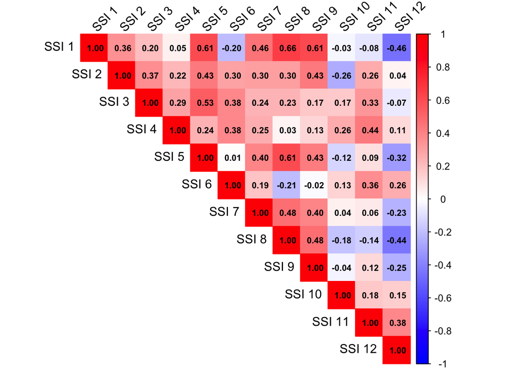

```r
corrplot(cate_cor, method = "color", type = "upper",
         tl.col = "black", tl.srt = 45, addCoef.col = "black",
         number.cex = 0.7,
         col = colorRampPalette(c("blue", "white", "red"))(200))
```

# 6 Latent profile analysis (LPA) on CATE matrix

Standardize the 12 CATE columns and fit `mclust::Mclust(G = 1:10)` across 10 seeds; keep the best-BIC run as `mod_train`.

```r
X_train <- scale(as.matrix(df_cate %>% select(-pid)))

mod_train <- {
  n_runs <- 10
  models <- vector("list", n_runs)
  for (i in 1:n_runs) {
    set.seed(123 + i)
    models[[i]] <- Mclust(X_train, G = 1:10)
  }
  bics <- sapply(models, function(m) m$bic)
  best <- which.max(bics)
  models[[best]]
}

cat("Best LPA: G =", mod_train$G,
    " modelName =", mod_train$modelName,
    " BIC =", round(mod_train$bic, 1), "\n")
```

```
Best LPA: G = 4  modelName = VEV  BIC = -214478.8
```

```r
# Compare solutions across G and covariance parameterizations
cat("Top models by BIC (model, G):\n")
```

```
Top models by BIC (model, G):
```

```r
print(summary(mod_train$BIC))
```

```
Best BIC values:
             VEV,4        VEV,5        VVV,4
BIC      -214478.8 -214598.4785 -214625.5675
BIC diff       0.0    -119.6512    -146.7402
```

```r
cat("\nFull BIC matrix (rows = G, cols = covariance model):\n")
```

```
Full BIC matrix (rows = G, cols = covariance model):
```

```r
print(round(mod_train$BIC, 1))
```

```
Bayesian Information Criterion (BIC):
         EII       VII       EEI       VEI       EVI       VVI       EEE
1  -255683.2 -255683.2 -255781.4 -255781.4 -255781.4 -255781.4 -220334.3
2  -243454.5 -243460.6 -241443.6 -241450.4 -239901.8 -239912.2 -217853.2
3  -236078.4 -235860.6 -234766.0 -234541.8 -233287.6 -233092.9 -217160.9
4  -232879.1 -232652.3 -230360.9 -230301.1 -229537.0 -229455.0 -216421.4
5  -230748.3 -230601.8 -228484.5 -228372.0 -227598.7 -227445.9 -216190.8
6  -229785.1 -229458.8 -227124.3 -226945.0 -226272.6 -226151.7 -215509.4
7  -228337.1 -228268.6 -226504.5 -225679.9 -225591.4 -225032.7 -215448.2
8  -227505.0 -227225.0 -224849.4 -224698.5 -224420.2 -224249.2 -215388.6
9  -226883.2 -226762.2 -224342.1 -224232.1 -223799.2 -223732.3 -215162.4
10 -226123.3 -225934.3 -223696.0 -223573.6 -223319.1 -223049.2 -215084.3
         VEE       EVE       VVE       EEV       VEV       EVV       VVV
1  -220334.3 -220334.3 -220334.3 -220334.3 -220334.3 -220334.3 -220334.3
2  -217861.7 -217102.7 -217110.6 -215622.5 -215626.9 -215620.6 -215619.1
3  -217157.6 -216713.7 -216730.7 -214801.2 -214764.9 -214891.2 -214847.9
4  -216398.3 -216027.7 -216028.5 -214716.9 -214478.8 -214813.9 -214625.6
5  -215977.2 -215650.9 -215918.0 -215064.1 -214598.5 -214897.0 -214707.6
6  -215846.2 -215480.7 -215651.4 -214800.6 -214781.5 -215208.0 -215077.5
7  -215414.8 -215256.9 -215176.7 -215176.5 -215084.3 -215496.2 -215394.9
8  -215327.9 -215175.2 -215140.0 -215574.8 -215549.3 -215898.0 -215941.4
9  -215180.4 -215106.8 -215080.9 -215981.3 -215815.9 -216501.6 -216451.4
10 -215039.0 -214985.8 -214941.5 -216249.2 -216293.1 -216950.9 -216953.6

Top 3 models based on the BIC criterion:
    VEV,4     VEV,5     VVV,4
-214478.8 -214598.5 -214625.6
```

```r
cl_train <- mod_train$classification
df_cate$cluster_assignment <- cl_train

mydata <- mydata %>%
  left_join(df_cate %>% select(pid, cluster_assignment), by = "pid")

cat("\nCluster sizes:\n")
```

```
Cluster sizes:
```

```r
print(table(mydata$cluster_assignment))
```

```
   1    2    3    4
1777 1475 1554 2699
```

## 6.1 Figure 1 — CATE profiles by cluster

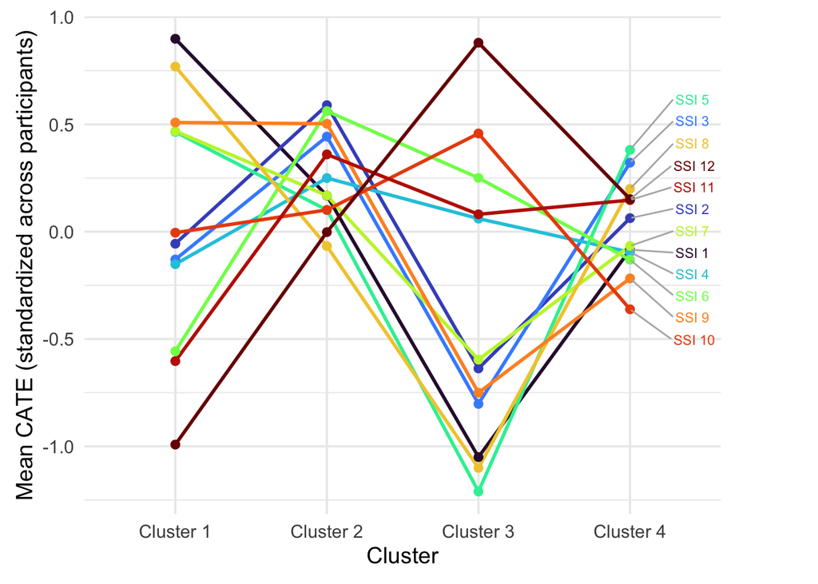

```r
cluster_means_df <- as.data.frame(mod_train$parameters$mean)
colnames(cluster_means_df) <- paste("Cluster", seq_len(mod_train$G))
cluster_means_df_t <- t(cluster_means_df)
cluster_means_long <- reshape2::melt(cluster_means_df_t)
colnames(cluster_means_long) <- c("Cluster", "Variable", "Mean")
cluster_means_long$Cluster <- factor(cluster_means_long$Cluster)

last_points <- cluster_means_long %>%
  group_by(Variable) %>%
  filter(Cluster == last(levels(Cluster)))

fig1 <- ggplot(cluster_means_long,
               aes(x = Cluster, y = Mean, color = Variable, group = Variable)) +
  geom_line(linewidth = 1) +
  geom_point(size = 2) +
  geom_text_repel(
    data = last_points,
    aes(label = gsub("CATE_", "SSI ", Variable)),
    nudge_x = 0.3, direction = "y", hjust = 0,
    segment.color = "grey70", size = 3
  ) +
  labs(x = "Cluster",
       y = "Mean CATE (standardized across participants)") +
  scale_color_viridis_d(option = "turbo") +
  theme_minimal(base_size = 14) +
  theme(legend.position = "none",
        plot.margin = margin(10, 60, 10, 10))

ggsave(file.path(FIGURES_DIR, "cate_profiles.png"),
       fig1, width = 9, height = 6, dpi = 300)

fig1
```

## 6.2 Supplementary Table 5 — Mean CATEs by SSI and cluster

```r
mean_cate_tbl <- as.data.frame(mod_train$parameters$mean) %>%
  setNames(paste("Cluster", seq_len(mod_train$G))) %>%
  tibble::rownames_to_column("ssi") %>%
  mutate(
    ssi_num = as.integer(str_extract(ssi, "\\d+")),
    No.     = ssi_num,
    SSI     = ssi_labels[ssi_num],
    Target  = case_when(
      ssi_num %in% c(1, 5, 7, 8, 9) ~ "Cluster 1",
      ssi_num %in% c(10, 12)         ~ "Cluster 3",
      TRUE                           ~ ""
    )
  ) %>%
  arrange(ssi_num) %>%
  mutate(across(starts_with("Cluster "), \(x) round(x, 2))) %>%
  select(No., SSI, Target,
         `Cluster 1`, `Cluster 2`, `Cluster 3`, `Cluster 4`)

print(mean_cate_tbl)
```

```
   No.                                   SSI    Target Cluster 1 Cluster 2
1    1           5 Habits to Beat Depression Cluster 1      0.90      0.17
2    2    AI-assisted Personalized Narrative               -0.06      0.59
3    3                 Behavioral Activation               -0.13      0.44
4    4 Dialectical Behavioral Therapy Skills               -0.15      0.25
5    5              Inner Child Healing Walk Cluster 1      0.46      0.10
6    6     Interactive Cognitive Reappraisal               -0.56      0.56
7    7                    Mindful Acceptance Cluster 1      0.47      0.17
8    8              Mindful Attention Skills Cluster 1      0.77     -0.07
9    9                       Moral Elevation Cluster 1      0.51      0.50
10  10 Personalized Intervention Recommender Cluster 3      0.00      0.10
11  11           Reframing Negative Thoughts               -0.60      0.36
12  12                   Savoring Strategies Cluster 3     -0.99      0.00
   Cluster 3 Cluster 4
1      -1.05     -0.08
2      -0.64      0.06
3      -0.80      0.32
4       0.06     -0.10
5      -1.21      0.38
6       0.25     -0.13
7      -0.60     -0.07
8      -1.10      0.20
9      -0.75     -0.22
10      0.46     -0.36
11      0.08      0.15
12      0.88      0.15
```

```r
write.csv(mean_cate_tbl,
          file.path(TABLES_DIR, "supp_table5_mean_cates.csv"),
          row.names = FALSE)
```

## 6.3 Supplementary Table 3 — Classification quality

Per-cluster mean modal posterior probability and relative entropy ($1 - \bar{H}_k / \log K$; higher = better separation).

```r
post <- as.data.frame(mod_train$z)
colnames(post) <- paste0("p_cl", seq_len(ncol(post)))

K <- mod_train$G
dat_post <- mydata %>%
  bind_cols(post) %>%
  mutate(
    max_prob = apply(select(., starts_with("p_cl")), 1, max),
    entropy  = apply(select(., starts_with("p_cl")), 1,
                     function(p) -sum(ifelse(p > 0, p * log(p), 0)))
  )

supp_table3 <- dat_post %>%
  group_by(cluster_assignment) %>%
  summarise(
    n                    = n(),
    mean_max_posterior   = mean(max_prob),
    median_max_posterior = median(max_prob),
    mean_entropy         = mean(entropy),
    relative_entropy     = 1 - mean(entropy) / log(K),
    .groups = "drop"
  )

print(supp_table3, digits = 3)
```

```
# A tibble: 4 × 6
  cluster_assignment     n mean_max_posterior median_max_posterior mean_entropy
               <dbl> <int>              <dbl>                <dbl>        <dbl>
1                  1  1777              0.828                0.896        0.414
2                  2  1475              0.752                0.765        0.569
3                  3  1554              0.871                0.964        0.308
4                  4  2699              0.769                0.802        0.587
# ℹ 1 more variable: relative_entropy <dbl>
```

```r
write.csv(supp_table3,
          file.path(TABLES_DIR, "supp_table3_lpa_classification.csv"),
          row.names = FALSE)
```

# 7 Overall ATE checks

```r
# 1) Any SSI vs control
lm_binary <- lm(phq9_score_followup ~ phq9_pre_rev + int_binary,
                data = mydata, weights = w_norm)
cat("=== Any SSI vs Control ===\n")
```

```
=== Any SSI vs Control ===
```

```r
print(tidy(lm_binary) %>% filter(term == "int_binary"), digits = 3)
```

```
# A tibble: 1 × 5
  term       estimate std.error statistic p.value
  <chr>         <dbl>     <dbl>     <dbl>   <dbl>
1 int_binary    0.328     0.167      1.96  0.0501
```

```r
# 2) 12-arm omnibus among intervention arms only
dat_int <- subset(mydata, group_numeric != "13")
dat_int$group_int_f <- factor(dat_int$group_numeric)
lm_int_only <- lm(phq9_score_followup ~ phq9_pre_rev + group_int_f,
                  data = dat_int, weights = w_norm)
cat("\n=== Omnibus across 12 SSIs (intervention arms only) ===\n")
```

```
=== Omnibus across 12 SSIs (intervention arms only) ===
```

```r
print(car::Anova(lm_int_only, type = 2))
```

```
Anova Table (Type II tests)

Response: phq9_score_followup
             Sum Sq   Df   F value Pr(>F)
phq9_pre_rev  37645    1 1406.0158 <2e-16 ***
group_int_f     198   11    0.6714  0.767
Residuals    126803 4736
---
Signif. codes:  0 '***' 0.001 '**' 0.01 '*' 0.05 '.' 0.1 ' ' 1
```

## 7.1 Supplementary Table 4 — Per-arm vs control with FDR

```r
mydata$group_f <- factor(mydata$group_numeric)
mydata$group_f <- relevel(mydata$group_f, ref = "13")

lm_main   <- lm(phq9_score_followup ~ phq9_pre_rev + group_f,
                data = mydata, weights = w_norm)
coef_tab  <- summary(lm_main)$coefficients
ssi_rows  <- grep("^group_f", rownames(coef_tab))

supp_table4 <- data.frame(
  ssi    = gsub("group_f", "SSI ", rownames(coef_tab)[ssi_rows]),
  b      = coef_tab[ssi_rows, "Estimate"],
  se     = coef_tab[ssi_rows, "Std. Error"],
  t      = coef_tab[ssi_rows, "t value"],
  p_raw  = coef_tab[ssi_rows, "Pr(>|t|)"]
) %>%
  mutate(p_fdr = p.adjust(p_raw, method = "BH")) %>%
  arrange(p_raw) %>%
  mutate(
    ssi_num = as.integer(gsub("SSI ", "", ssi)),
    ssi     = paste0(ssi_num, ". ", ssi_labels[ssi_num])
  ) %>%
  select(-ssi_num)

print(supp_table4, digits = 3)
```

```
                                                ssi      b    se      t  p_raw
group_f6       6. Interactive Cognitive Reappraisal 0.7045 0.308 2.2885 0.0221
group_f8                8. Mindful Attention Skills 0.6336 0.301 2.1034 0.0355
group_f7                      7. Mindful Acceptance 0.4821 0.300 1.6076 0.1080
group_f10 10. Personalized Intervention Recommender 0.4323 0.304 1.4227 0.1549
group_f4   4. Dialectical Behavioral Therapy Skills 0.4048 0.302 1.3398 0.1804
group_f9                         9. Moral Elevation 0.3145 0.303 1.0381 0.2993
group_f2      2. AI-assisted Personalized Narrative 0.2948 0.301 0.9796 0.3273
group_f3                   3. Behavioral Activation 0.2740 0.299 0.9170 0.3592
group_f1             1. 5 Habits to Beat Depression 0.2499 0.302 0.8264 0.4086
group_f12                   12. Savoring Strategies 0.1317 0.296 0.4444 0.6568
group_f11           11. Reframing Negative Thoughts 0.0471 0.299 0.1574 0.8749
group_f5                5. Inner Child Healing Walk 0.0139 0.298 0.0469 0.9626
          p_fdr
group_f6  0.213
group_f8  0.213
group_f7  0.432
group_f10 0.433
group_f4  0.433
group_f9  0.539
group_f2  0.539
group_f3  0.539
group_f1  0.545
group_f12 0.788
group_f11 0.954
group_f5  0.963
```

```r
write.csv(supp_table4,
          file.path(TABLES_DIR, "supp_table4_per_arm_fdr.csv"),
          row.names = FALSE)
```

# 8 Cluster-specific intervention effects → Table 3

```r
targets <- list(
  "1" = c("1", "5", "7", "8", "9"),
  "2" = c("2", "3", "6", "9", "11"),
  "3" = c("10", "12"),
  "4" = c("3", "5")
)

mydata$cluster_assignment <- factor(mydata$cluster_assignment)
mydata$group_numeric_chr  <- as.character(mydata$group_numeric)

cluster_subsets <- list(
  d1 = subset(mydata, cluster_assignment == "1"),
  d2 = subset(mydata, cluster_assignment == "2"),
  d3 = subset(mydata, cluster_assignment == "3"),
  d4 = subset(mydata, cluster_assignment == "4")
)

# Helper closures
fit_binary <- function(d) {
  d$int_binary <- ifelse(d$group_numeric_chr == "13", 0, 1)
  mod <- lm(phq9_score_followup ~ phq9_pre_rev + int_binary,
            data = d, weights = w_norm)
  tidy(mod) %>% filter(term == "int_binary")
}

fit_target <- function(d, tgt) {
  d$int_binary <- ifelse(d$group_numeric_chr == "13", 0, 1)
  d$int_target <- ifelse(d$group_numeric_chr %in% tgt, 1, 0)
  mod <- lm(phq9_score_followup ~ phq9_pre_rev + int_binary + int_target,
            data = d, weights = w_norm)
  tidy(mod) %>% filter(term == "int_target")
}

fit_emm_pairs <- function(d, tgt) {
  d$trt_3cat <- factor(
    ifelse(d$group_numeric_chr == "13", "control",
           ifelse(d$group_numeric_chr %in% tgt, "target", "other_int")),
    levels = c("control", "other_int", "target")
  )
  mod <- lm(phq9_score_followup ~ phq9_pre_rev + trt_3cat,
            data = d, weights = w_norm)
  # reverse = TRUE: contrasts read intervention - control (positive = improvement)
  pairs(emmeans(mod, specs = "trt_3cat"), reverse = TRUE) %>% as.data.frame()
}

fit_ftest <- function(d, tgt) {
  d$int_binary <- ifelse(d$group_numeric_chr == "13", 0, 1)
  d$int_target <- ifelse(d$group_numeric_chr %in% tgt, 1, 0)
  mod_base   <- lm(phq9_score_followup ~ phq9_pre_rev + int_binary,
                   data = d, weights = w_norm)
  mod_target <- lm(phq9_score_followup ~ phq9_pre_rev + int_binary + int_target,
                   data = d, weights = w_norm)
  a <- anova(mod_base, mod_target)
  data.frame(delta_F = a$F[2], df1 = a$Df[2], df_resid = a$Res.Df[2],
             p.value = a$`Pr(>F)`[2])
}

# Format helpers
fmt_p_tbl <- function(p) {
  if (is.na(p)) return(NA_character_)
  if (p < .001) return("< .001")
  sub("^0\\.", ".", sprintf("%.3f", p))
}
n_completers <- function(d) sum(!is.na(d$phq9_score_followup))
indent <- strrep("\u00A0", 4)   # non-breaking spaces so sub-rows indent in HTML/Word

# Compute models for all clusters
m1 <- lapply(seq_along(cluster_subsets),
             function(i) fit_binary(cluster_subsets[[i]]))
m2 <- lapply(seq_along(cluster_subsets),
             function(i) fit_target(cluster_subsets[[i]],
                                    targets[[as.character(i)]]))
emm_list <- lapply(seq_along(cluster_subsets),
                   function(i) fit_emm_pairs(cluster_subsets[[i]],
                                             targets[[as.character(i)]]))
ftests <- lapply(seq_along(cluster_subsets),
                 function(i) fit_ftest(cluster_subsets[[i]],
                                       targets[[as.character(i)]]))

# Cluster metadata
cluster_meta <- list(
  list(label = "Cluster 1 (primary)",     targets_str = "1, 5, 7, 8, 9"),
  list(label = "Cluster 2 (exploratory)", targets_str = "2, 3, 6, 9, 11"),
  list(label = "Cluster 3 (primary)",     targets_str = "10, 12"),
  list(label = "Cluster 4 (exploratory)", targets_str = "3, 5")
)

# Build long-format table (Metric | b | SE | t | p)
long_rows <- list()
for (i in 1:4) {
  n_c <- n_completers(cluster_subsets[[i]])
  ft  <- ftests[[i]]
  hdr <- sprintf("%s (n = %d; target SSIs: %s)",
                 cluster_meta[[i]]$label, n_c, cluster_meta[[i]]$targets_str)

  long_rows[[length(long_rows) + 1]] <- data.frame(
    Metric = hdr, b = NA_real_, SE = NA_real_, t = NA_real_,
    p = NA_character_, stringsAsFactors = FALSE)

  long_rows[[length(long_rows) + 1]] <- data.frame(
    Metric = paste0(indent, "Any SSI vs. control"),
    b  = round(m1[[i]]$estimate,  2),
    SE = round(m1[[i]]$std.error, 2),
    t  = round(m1[[i]]$statistic, 2),
    p  = fmt_p_tbl(m1[[i]]$p.value),
    stringsAsFactors = FALSE)

  long_rows[[length(long_rows) + 1]] <- data.frame(
    Metric = paste0(indent, "Target SSI (incremental)"),
    b  = round(m2[[i]]$estimate,  2),
    SE = round(m2[[i]]$std.error, 2),
    t  = round(m2[[i]]$statistic, 2),
    p  = fmt_p_tbl(m2[[i]]$p.value),
    stringsAsFactors = FALSE)

  long_rows[[length(long_rows) + 1]] <- data.frame(
    Metric = sprintf("%sModel fit improvement: ΔF(%d, %d) = %.2f",
                     indent, ft$df1, ft$df_resid, ft$delta_F),
    b = NA_real_, SE = NA_real_, t = NA_real_,
    p = fmt_p_tbl(ft$p.value),
    stringsAsFactors = FALSE)

  for (cname in c("target - control", "other_int - control", "target - other_int")) {
    lbl <- switch(cname,
      "target - control"    = paste0(indent, "Target SSIs vs. control"),
      "other_int - control" = paste0(indent, "Other SSIs vs. control"),
      "target - other_int"  = paste0(indent, "Target SSIs vs. other SSIs"))
    crow <- emm_list[[i]] %>% filter(contrast == cname)
    if (nrow(crow) == 0) next
    long_rows[[length(long_rows) + 1]] <- data.frame(
      Metric = lbl,
      b  = round(crow$estimate, 2),
      SE = round(crow$SE,       2),
      t  = round(crow$t.ratio,  2),
      p  = fmt_p_tbl(crow$p.value),
      stringsAsFactors = FALSE)
  }
}

table3 <- do.call(rbind, long_rows)
rownames(table3) <- NULL
print(table3)
```

```
                                                            Metric     b   SE
1       Cluster 1 (primary) (n = 1516; target SSIs: 1, 5, 7, 8, 9)    NA   NA
2                                              Any SSI vs. control  0.68 0.34
3                                         Target SSI (incremental)  0.67 0.31
4                        Model fit improvement: ΔF(1, 1512) = 4.60    NA   NA
5                                          Target SSIs vs. control  1.08 0.39
6                                           Other SSIs vs. control  0.41 0.36
7                                       Target SSIs vs. other SSIs  0.67 0.31
8  Cluster 2 (exploratory) (n = 1155; target SSIs: 2, 3, 6, 9, 11)    NA   NA
9                                              Any SSI vs. control  0.48 0.38
10                                        Target SSI (incremental)  0.38 0.37
11                       Model fit improvement: ΔF(1, 1151) = 1.09    NA   NA
12                                         Target SSIs vs. control  0.71 0.44
13                                          Other SSIs vs. control  0.32 0.41
14                                      Target SSIs vs. other SSIs  0.38 0.37
```

[output cut: 43 more lines]

```r
write.csv(table3,
          file.path(TABLES_DIR, "table3_cluster_effects.csv"),
          row.names = FALSE)

# Cluster × target-intervention interaction (Cluster 1 follow-up reported in text)
dat_target <- subset(mydata, group_numeric_chr == "13" |
                              group_numeric_chr %in% targets[["1"]])
dat_target$int_target <- ifelse(dat_target$group_numeric_chr == "13", 0, 1)
lm_target_cluster <- lm(
  phq9_score_followup ~ phq9_pre_rev + cluster_assignment * int_target,
  data    = dat_target,
  weights = w_norm
)
cat("\n=== Cluster × Target-intervention (Cluster 1 targets) interaction ===\n")
```

```
=== Cluster × Target-intervention (Cluster 1 targets) interaction ===
```

```r
print(car::Anova(lm_target_cluster, type = 2))
```

```
Anova Table (Type II tests)

Response: phq9_score_followup
                              Sum Sq   Df  F value    Pr(>F)
phq9_pre_rev                   17473    1 659.2896 < 2.2e-16 ***
cluster_assignment               935    3  11.7653 1.156e-07 ***
int_target                        83    1   3.1417  0.076409 .
cluster_assignment:int_target    309    3   3.8924  0.008652 **
Residuals                      84330 3182
---
Signif. codes:  0 '***' 0.001 '**' 0.01 '*' 0.05 '.' 0.1 ' ' 1
```

```r
print(pairs(emmeans(lm_target_cluster, ~ int_target | cluster_assignment), reverse = TRUE))
```

```
cluster_assignment = 1:
 contrast                  estimate    SE   df t.ratio p.value
 int_target1 - int_target0    1.077 0.385 3182   2.796  0.0052

cluster_assignment = 2:
 contrast                  estimate    SE   df t.ratio p.value
 int_target1 - int_target0    0.789 0.411 3182   1.922  0.0547

cluster_assignment = 3:
 contrast                  estimate    SE   df t.ratio p.value
 int_target1 - int_target0   -0.743 0.425 3182  -1.748  0.0806

cluster_assignment = 4:
 contrast                  estimate    SE   df t.ratio p.value
 int_target1 - int_target0    0.159 0.315 3182   0.504  0.6142
```

```r
# Cluster × target-intervention interaction (Cluster 3 follow-up reported in text)
dat_target_c3 <- subset(mydata, group_numeric_chr == "13" |
                                 group_numeric_chr %in% targets[["3"]])
dat_target_c3$int_target <- ifelse(dat_target_c3$group_numeric_chr == "13", 0, 1)
lm_target_cluster_c3 <- lm(
  phq9_score_followup ~ phq9_pre_rev + cluster_assignment * int_target,
  data    = dat_target_c3,
  weights = w_norm
)
cat("\n=== Cluster × Target-intervention (Cluster 3 targets) interaction ===\n")
```

```
=== Cluster × Target-intervention (Cluster 3 targets) interaction ===
```

```r
print(car::Anova(lm_target_cluster_c3, type = 2))
```

```
Anova Table (Type II tests)

Response: phq9_score_followup
                              Sum Sq   Df  F value  Pr(>F)
phq9_pre_rev                    9683    1 359.6570 < 2e-16 ***
cluster_assignment              2168    3  26.8362 < 2e-16 ***
int_target                        31    1   1.1491 0.28387
cluster_assignment:int_target    212    3   2.6187 0.04937 *
Residuals                      53792 1998
---
Signif. codes:  0 '***' 0.001 '**' 0.01 '*' 0.05 '.' 0.1 ' ' 1
```

```r
print(pairs(emmeans(lm_target_cluster_c3, ~ int_target | cluster_assignment), reverse = TRUE))
```

```
cluster_assignment = 1:
 contrast                  estimate    SE   df t.ratio p.value
 int_target1 - int_target0   0.0803 0.474 1998   0.170  0.8654

cluster_assignment = 2:
 contrast                  estimate    SE   df t.ratio p.value
 int_target1 - int_target0  -0.9302 0.542 1998  -1.717  0.0862

cluster_assignment = 3:
 contrast                  estimate    SE   df t.ratio p.value
 int_target1 - int_target0   1.0597 0.516 1998   2.054  0.0401

cluster_assignment = 4:
 contrast                  estimate    SE   df t.ratio p.value
 int_target1 - int_target0   0.5408 0.402 1998   1.346  0.1783
```

# 9 Cluster characterization — LASSO

Binary LASSO logistic regressions (cluster *k* vs. rest) with 10-fold CV (`tidymodels`/`glmnet`), using baseline scale totals plus demographics; item-level covariates that roll up into totals are dropped.

```r
dat_post <- dat_post %>%
  mutate(
    hopeless_score_baseline = q1_beck_baseline + q2_beck_baseline +
                              q3_beck_baseline + q4_beck_baseline,
    fats_score_baseline     = rowSums(across(fats_1_baseline:fats_12_baseline)),
    readiness_score_baseline = ready_important_baseline + ready_confident_baseline,
    agency_score_baseline    = agency_q1_baseline + agency_q2_baseline +
                               agency_q3_baseline,
    dep_expectancies_score_baseline = expect_donthelp_r_baseline +
                                       expect_wontwork_r_baseline +
                                       expect_positive_baseline
  )

drop_items <- c(
  paste0("phq9_", 1:9, "_baseline"),
  paste0("q", 1:4, "_beck_baseline"),
  paste0("fats_", 1:12, "_baseline"),
  paste0("agency_q", 1:3, "_baseline"),
  c("ready_important_baseline", "ready_confident_baseline",
    "expect_donthelp_r_baseline", "expect_wontwork_r_baseline",
    "expect_positive_baseline")
)

scale_totals <- c(
  "phq9_pre_rev", "hopeless_score_baseline", "fats_score_baseline",
  "readiness_score_baseline", "agency_score_baseline",
  "dep_expectancies_score_baseline", "ffmq_distressing_baseline"
)

lasso_predictors <- function(data) {
  # Defense-in-depth: also strip any `c\d+_binary` cluster indicators that
  # might have been added downstream — they would leak the outcome.
  drop_cols <- c("pid", "w_norm", "cluster_assignment",
                 "phq9_score_followup", "fup_complete", "int_binary",
                 "phq9_pre_raw", "group_numeric", "group_f",
                 "group_numeric_chr",
                 grep("^p_cl",       names(data), value = TRUE),
                 grep("^c\\d+_binary$", names(data), value = TRUE),
                 "max_prob", "entropy")
  candidates <- setdiff(names(data),
                        c(drop_cols, intersect(names(data), drop_items)))
  unique(c(candidates, intersect(scale_totals, names(data))))
}

run_lasso <- function(data, target_cluster, seed = 123) {
  preds <- lasso_predictors(data)
  d <- data %>%
    mutate(target = factor(if_else(cluster_assignment == target_cluster,
                                    "Target", "Other"))) %>%
    select(target, all_of(preds))

  set.seed(seed)
  rec <- recipe(target ~ ., data = d) %>%
    step_nzv(all_predictors()) %>%
    step_dummy(all_nominal_predictors()) %>%
    step_normalize(all_numeric_predictors())
  spec <- logistic_reg(mode = "classification",
                       penalty = tune(), mixture = 1) %>%
    set_engine("glmnet")
  wf    <- workflow() %>% add_recipe(rec) %>% add_model(spec)
  folds <- vfold_cv(d, v = 10, strata = target)
  grid  <- grid_regular(penalty(), levels = 60)
  res   <- tune_grid(wf, resamples = folds, grid = grid,
                     metrics = metric_set(roc_auc))
  best  <- select_best(res, metric = "roc_auc")
  fit_final <- finalize_workflow(wf, best) %>% fit(d)
  tidy(fit_final) %>%
    filter(term != "(Intercept)", estimate != 0) %>%
    mutate(abs_est = abs(estimate)) %>%
    arrange(desc(abs_est))
}
```

## 9.1 Cluster 1 LASSO

```r
var_labels <- c(
  phq9_pre_rev                    = "Baseline PHQ-9 (reverse scored)",
  fats_score_baseline             = "FATS",
  agency_score_baseline           = "Agency — State Hope Scale",
  hopeless_score_baseline         = "Hopelessness — BHS-4",
  dep_expectancies_score_baseline = "Depression change expectancies — DCES",
  age_baseline                    = "Age",
  income_ordered_baseline         = "Household income (ordered)",
  social_ladder_baseline          = "MacArthur Social Ladder",
  education_ordered_baseline      = "Education (ordered)",
  disability_yes_baseline         = "Disability or chronic condition",
  help_mental_health_app_baseline = "Prior mental health app use",
  help_online_resource_baseline   = "Prior online mental health resource use",
  gender_woman_baseline           = "Gender: woman",
  gender_man_baseline             = "Gender: man",
  political_party_independent_baseline    = "Political Party: Independent",
  political_party_republican_baseline     = "Political Party: Republican",
  political_party_something_else_baseline = "Political Party: Something else",
  race_white_baseline                     = "Race: White",
  race_black_baseline                     = "Race: Black",
  ethnicity_not_hispanic_baseline         = "Ethnicity: Not Hispanic/Latino",
  ethnicity_mexican_baseline              = "Ethnicity: Mexican",
  employment_student_baseline             = "Employment: Student",
  employment_full_time_baseline           = "Employment: Full-time",
  employment_part_time_baseline           = "Employment: Part-time",
  employment_unemployed_baseline          = "Employment: Unemployed",
  employment_not_in_paid_work_baseline    = "Employment: Not in paid work",
  marital_status_in_relationship_baseline = "Marital Status: In a relationship",
  marital_status_married_baseline         = "Marital Status: Married",
  marital_status_divorced_baseline        = "Marital Status: Divorced",
  help_support_group_baseline             = "Prior help: Support group",
  help_phone_text_baseline                = "Prior help: Phone/text line",
  help_therapist_baseline                 = "Prior help: Therapist",
  help_medical_doctor_baseline            = "Prior help: Medical doctor",
  help_book_video_baseline                = "Prior help: Book/video",
  help_no_formal_support_baseline         = "Prior help: No formal support",
  readiness_score_baseline                = "Readiness to change",
  ffmq_distressing_baseline               = "FFMQ — Non-reactivity to distressing thoughts",
  recruitment_platform_prolific_baseline  = "Recruitment platform: Prolific"
)
relabel_terms <- function(df) {
  df %>% mutate(term = ifelse(
    term %in% names(var_labels),
    var_labels[term],
    gsub("_baseline$", "", gsub("_", " ", term))
  ))
}

lasso_c1 <- run_lasso(dat_post, target_cluster = 1, seed = 123)
print(lasso_c1, n = Inf)
```

```
# A tibble: 24 × 4
   term                                    estimate penalty  abs_est
   <chr>                                      <dbl>   <dbl>    <dbl>
 1 fats_score_baseline                    -2.06     0.00194 2.06
 2 phq9_pre_rev                           -0.938    0.00194 0.938
 3 age_baseline                            0.629    0.00194 0.629
 4 agency_score_baseline                  -0.618    0.00194 0.618
 5 dep_expectancies_score_baseline        -0.601    0.00194 0.601
 6 hopeless_score_baseline                 0.479    0.00194 0.479
 7 income_ordered_baseline                -0.428    0.00194 0.428
 8 social_ladder_baseline                 -0.343    0.00194 0.343
 9 help_mental_health_app_baseline        -0.187    0.00194 0.187
10 help_online_resource_baseline          -0.138    0.00194 0.138
11 employment_student_baseline            -0.136    0.00194 0.136
12 political_party_independent_baseline    0.127    0.00194 0.127
13 race_white_baseline                     0.112    0.00194 0.112
14 help_support_group_baseline             0.110    0.00194 0.110
15 help_phone_text_baseline               -0.0998   0.00194 0.0998
16 education_ordered_baseline              0.0795   0.00194 0.0795
17 readiness_score_baseline               -0.0502   0.00194 0.0502
18 recruitment_platform_prolific_baseline -0.0278   0.00194 0.0278
19 race_black_baseline                     0.0231   0.00194 0.0231
20 help_no_formal_support_baseline        -0.0153   0.00194 0.0153
21 ffmq_distressing_baseline              -0.0127   0.00194 0.0127
22 employment_full_time_baseline           0.00785  0.00194 0.00785
23 ethnicity_not_hispanic_baseline         0.00424  0.00194 0.00424
24 political_party_republican_baseline    -0.000183 0.00194 0.000183
```

```r
write.csv(relabel_terms(lasso_c1),
          file.path(TABLES_DIR, "supp_table6_lasso_cluster1.csv"),
          row.names = FALSE)
```

## 9.2 Cluster 3 LASSO

```r
lasso_c3 <- run_lasso(dat_post, target_cluster = 3, seed = 123)
print(lasso_c3, n = Inf)
```

```
# A tibble: 36 × 4
   term                                     estimate  penalty  abs_est
   <chr>                                       <dbl>    <dbl>    <dbl>
 1 fats_score_baseline                      3.53     0.000890 3.53
 2 agency_score_baseline                    1.25     0.000890 1.25
 3 hopeless_score_baseline                 -0.350    0.000890 0.350
 4 phq9_pre_rev                            -0.306    0.000890 0.306
 5 political_party_republican_baseline      0.236    0.000890 0.236
 6 income_ordered_baseline                 -0.225    0.000890 0.225
 7 dep_expectancies_score_baseline          0.218    0.000890 0.218
 8 help_support_group_baseline             -0.182    0.000890 0.182
 9 recruitment_platform_prolific_baseline  -0.118    0.000890 0.118
10 education_ordered_baseline               0.113    0.000890 0.113
11 race_black_baseline                     -0.0969   0.000890 0.0969
12 ffmq_distressing_baseline               -0.0962   0.000890 0.0962
```

[output cut: 24 more lines]

```r
write.csv(relabel_terms(lasso_c3),
          file.path(TABLES_DIR, "supp_table7_lasso_cluster3.csv"),
          row.names = FALSE)
```

# 10 SSI characteristics by target / non-target → Supplementary Table 8

```r
ssi_char <- read.csv(file.path(DATA_DIR, "ssi_characteristics.csv"),
                     header = TRUE) %>%
  mutate(group_numeric = case_when(
    str_detect(Program_Name, "5 Habits")              ~ 1,
    str_detect(Program_Name, "AI-assisted")           ~ 2,
    str_detect(Program_Name, "Behavioral Activation") ~ 3,
    str_detect(Program_Name, "Dialectical")           ~ 4,
    str_detect(Program_Name, "Inner Child")           ~ 5,
    str_detect(Program_Name, "Interactive Cognitive") ~ 6,
    str_detect(Program_Name, "Mindful Acceptance")    ~ 7,
    str_detect(Program_Name, "Mindful Attention")     ~ 8,
    str_detect(Program_Name, "Moral Elevation")       ~ 9,
    str_detect(Program_Name, "Personalized Intervention") ~ 10,
    str_detect(Program_Name, "Reframing Negative")    ~ 11,
    str_detect(Program_Name, "Savoring")              ~ 12,
    TRUE ~ NA_real_
  ))

continuous_vars <- c("Engagingness", "Interactive_Activities", "Effortful",
                     "Personalization", "Cognitive_Reframing",
                     "Behavioral_Activation", "Mindfulness")
binary_vars     <- c("Video_Audio", "References_Depression", "Links_to_Resources",
                     "Meditation_Practice", "Clinician_Created", "Take_Home_Reminder")

df_char <- ssi_char %>%
  mutate(
    target_c1 = if_else(group_numeric %in% c(1, 5, 7, 8, 9), "Target", "Other"),
    target_c3 = if_else(group_numeric %in% c(10, 12),       "Target", "Other"),
    across(all_of(binary_vars), ~ if_else(. == "Yes", 1L, 0L))
  )

summarize_by_target <- function(data, target_var) {
  cont_tbl <- data %>%
    group_by({{ target_var }}) %>%
    summarise(across(all_of(continuous_vars),
                     ~ sprintf("%.2f (%.2f)", mean(., na.rm = TRUE),
                                              sd(., na.rm = TRUE))),
              .groups = "drop") %>%
    pivot_longer(-{{ target_var }}, names_to = "Characteristic", values_to = "val") %>%
    pivot_wider(names_from = {{ target_var }}, values_from = "val") %>%
    mutate(type = "continuous")

  bin_tbl <- data %>%
    group_by({{ target_var }}) %>%
    summarise(across(all_of(binary_vars),
                     ~ sprintf("%d (%.0f%%)", sum(., na.rm = TRUE),
                                              100 * mean(., na.rm = TRUE))),
              .groups = "drop") %>%
    pivot_longer(-{{ target_var }}, names_to = "Characteristic", values_to = "val") %>%
    pivot_wider(names_from = {{ target_var }}, values_from = "val") %>%
    mutate(type = "binary")

  bind_rows(cont_tbl, bin_tbl) %>%
    arrange(type, Characteristic)
}

table_c1 <- summarize_by_target(df_char, target_c1) %>%
  rename(Other_C1 = Other, Target_C1 = Target)
table_c3 <- summarize_by_target(df_char, target_c3) %>%
  rename(Other_C3 = Other, Target_C3 = Target)

supp_table7 <- table_c1 %>%
  full_join(table_c3, by = c("Characteristic", "type"))

char_labels <- c(
  Engagingness           = "Engagingness",
  Interactive_Activities = "Interactive Activities",
  Effortful              = "Effortful",
  Personalization        = "Personalization",
  Cognitive_Reframing    = "Cognitive Reframing",
  Behavioral_Activation  = "Behavioral Activation",
  Mindfulness            = "Mindfulness",
  Video_Audio            = "Video/Audio",
  References_Depression  = "References Depression",
  Links_to_Resources     = "Links to Resources",
  Meditation_Practice    = "Meditation Practice",
  Clinician_Created      = "Clinician Created",
  Take_Home_Reminder     = "Take-Home Reminder"
)
supp_table7 <- supp_table7 %>%
  mutate(Characteristic = ifelse(Characteristic %in% names(char_labels),
                                  char_labels[Characteristic],
                                  Characteristic)) %>%
  select(-type)

print(supp_table7)
```

```
# A tibble: 13 × 5
   Characteristic         Other_C1    Target_C1   Other_C3    Target_C3
   <chr>                  <chr>       <chr>       <chr>       <chr>
 1 Clinician Created      4 (57%)     2 (40%)     5 (50%)     1 (50%)
 2 Links to Resources     3 (43%)     1 (20%)     2 (20%)     2 (100%)
 3 Meditation Practice    2 (29%)     2 (40%)     3 (30%)     1 (50%)
 4 References Depression  5 (71%)     3 (60%)     6 (60%)     2 (100%)
 5 Take-Home Reminder     3 (43%)     2 (40%)     3 (30%)     2 (100%)
 6 Video/Audio            2 (29%)     5 (100%)    7 (70%)     0 (0%)
 7 Behavioral Activation  2.00 (1.41) 3.00 (1.87) 2.60 (1.71) 1.50 (0.71)
 8 Cognitive Reframing    3.00 (1.73) 2.40 (1.52) 3.10 (1.52) 1.00 (0.00)
 9 Effortful              2.71 (0.76) 2.00 (1.00) 2.40 (0.97) 2.50 (0.71)
10 Engagingness           2.86 (0.69) 3.80 (0.84) 3.30 (0.95) 3.00 (0.00)
11 Interactive Activities 2.86 (1.21) 2.80 (1.30) 2.80 (1.23) 3.00 (1.41)
12 Mindfulness            2.00 (1.29) 3.40 (1.82) 2.70 (1.70) 2.00 (1.41)
13 Personalization        3.71 (1.38) 1.00 (0.00) 2.20 (1.62) 4.50 (0.71)
```

```r
write.csv(supp_table7,
          file.path(TABLES_DIR, "supp_table8_ssi_characteristics_by_target.csv"),
          row.names = FALSE)
```

# 11 Assignment-strategy comparison

Each strategy is benchmarked against control via a weighted regression of reverse-scored 4-week PHQ-9 on baseline PHQ-9 and a binary treatment indicator. HTE-informed strategies multiply the IPW weight by a design weight that corrects for the number of selected arms per cluster (`12 / k`) and re-calibrates the filtered sample’s cluster × treatment proportions to the full completer sample.

```r
# Step 1: full-sample target proportions
full_wtd_props <- mydata %>%
  filter(!is.na(phq9_score_followup)) %>%
  mutate(int_binary = ifelse(group_numeric_chr == "13", 0, 1)) %>%
  group_by(cluster_assignment, int_binary) %>%
  summarise(wsum_full = sum(w_norm), .groups = "drop") %>%
  mutate(wprop_full = wsum_full / sum(wsum_full))

# Single-strategy fitter that handles arm-count + ratio calibration
fit_strategy <- function(d, n_arms_lookup) {
  d <- d %>%
    filter(!is.na(phq9_score_followup)) %>%
    mutate(int_opt = ifelse(group_numeric_chr == "13", 0, 1)) %>%
    mutate(arm_correction = ifelse(int_opt == 1,
                                   12 / n_arms_lookup[as.character(cluster_assignment)],
                                   1),
           w_arm = w_norm * arm_correction)

  filt_props <- d %>%
    group_by(cluster_assignment, int_opt) %>%
    summarise(wsum_filt = sum(w_arm), .groups = "drop") %>%
    mutate(wprop_filt = wsum_filt / sum(wsum_filt)) %>%
    rename(int_binary = int_opt)

  d <- d %>%
    left_join(full_wtd_props %>% select(cluster_assignment, int_binary, wprop_full),
              by = c("cluster_assignment", "int_binary" = "int_binary")) %>%
    left_join(filt_props %>% select(cluster_assignment, int_binary, wprop_filt),
              by = c("cluster_assignment", "int_binary" = "int_binary")) %>%
    mutate(ratio = wprop_full / wprop_filt,
           w_combined = w_arm * ratio)

  mod <- lm(phq9_score_followup ~ phq9_pre_rev + int_opt,
            data = d, weights = w_combined)
  list(d = d, mod = mod,
       row = tidy(mod) %>% filter(term == "int_opt"))
}
```

```r
# Strategy 1: Random — any SSI vs control across the full sample
mydata_complete <- mydata %>% filter(!is.na(phq9_score_followup))
lm_s1 <- lm(phq9_score_followup ~ phq9_pre_rev + int_binary,
            data = mydata_complete, weights = w_norm)
s1_row <- tidy(lm_s1) %>% filter(term == "int_binary") %>%
  mutate(strategy = "1_random_assignment")

# Strategy 2: Best aggregate — SSIs 6 & 8 vs control
d_s2 <- mydata_complete %>%
  filter(group_numeric_chr %in% c("6", "8", "13")) %>%
  mutate(int_agg = ifelse(group_numeric_chr == "13", 0, 1))
lm_s2 <- lm(phq9_score_followup ~ phq9_pre_rev + int_agg,
            data = d_s2, weights = w_norm)
s2_row <- tidy(lm_s2) %>% filter(term == "int_agg") %>%
  mutate(strategy = "2_best_aggregate")

# Strategy 3: HTE-optimal in C1/C3, aggregate (6,8) in C2/C4
d_s3 <- mydata %>%
  filter(
    (cluster_assignment == "1" & group_numeric_chr %in% c("1","5","7","8","9","13")) |
    (cluster_assignment == "2" & group_numeric_chr %in% c("6","8","13"))             |
    (cluster_assignment == "3" & group_numeric_chr %in% c("10","12","13"))           |
    (cluster_assignment == "4" & group_numeric_chr %in% c("6","8","13"))
  )
fit_s3 <- fit_strategy(d_s3, c("1" = 5, "2" = 2, "3" = 2, "4" = 2))
s3_row <- fit_s3$row %>% mutate(strategy = "3_hte_plus_aggregate")

strategy_table <- bind_rows(s1_row, s2_row, s3_row) %>%
  transmute(strategy,
            b      = round(estimate,  3),
            se     = round(std.error, 3),
            t      = round(statistic, 3),
            p      = round(p.value,   4))

print(strategy_table)
```

```
# A tibble: 3 × 5
  strategy                 b    se     t      p
  <chr>                <dbl> <dbl> <dbl>  <dbl>
1 1_random_assignment  0.328 0.167  1.96 0.0501
2 2_best_aggregate     0.668 0.246  2.72 0.0066
3 3_hte_plus_aggregate 0.923 0.278  3.32 0.0009
```

## 11.1 Bootstrap pairwise contrasts (5,000 resamples)

```r
# Each bootstrap statistic re-fits both strategies on the resampled data
# and returns the difference in coefficients.

boot_diff_1v2 <- function(data, indices) {
  d <- data[indices, ]
  b1 <- coef(lm(phq9_score_followup ~ phq9_pre_rev + int_binary,
                data = d, weights = w_norm))["int_binary"]
  d_agg <- d %>% filter(group_numeric_chr %in% c("6","8","13")) %>%
    mutate(int_agg = ifelse(group_numeric_chr == "13", 0, 1))
  b2 <- coef(lm(phq9_score_followup ~ phq9_pre_rev + int_agg,
                data = d_agg, weights = w_norm))["int_agg"]
  unname(b2 - b1)
}

boot_strategy_3 <- function(d) {
  n_arms <- c("1" = 5, "2" = 2, "3" = 2, "4" = 2)
  d_opt <- d %>%
    filter(
      (cluster_assignment == "1" & group_numeric_chr %in% c("1","5","7","8","9","13")) |
      (cluster_assignment == "2" & group_numeric_chr %in% c("6","8","13"))             |
      (cluster_assignment == "3" & group_numeric_chr %in% c("10","12","13"))           |
      (cluster_assignment == "4" & group_numeric_chr %in% c("6","8","13"))
    ) %>%
    mutate(int_opt = ifelse(group_numeric_chr == "13", 0, 1),
           arm_correction = ifelse(int_opt == 1,
                                   12 / n_arms[as.character(cluster_assignment)],
                                   1),
           w_arm = w_norm * arm_correction)
  filt_props <- d_opt %>%
    group_by(cluster_assignment, int_opt) %>%
    summarise(wsum_filt = sum(w_arm), .groups = "drop") %>%
    mutate(wprop_filt = wsum_filt / sum(wsum_filt)) %>%
    rename(int_binary = int_opt)
  d_opt <- d_opt %>%
    left_join(full_wtd_props %>% select(cluster_assignment, int_binary, wprop_full),
              by = c("cluster_assignment", "int_binary")) %>%
    left_join(filt_props %>% select(cluster_assignment, int_binary, wprop_filt),
              by = c("cluster_assignment", "int_binary")) %>%
    mutate(ratio = wprop_full / wprop_filt,
           w_combined = w_arm * ratio)
  unname(coef(lm(phq9_score_followup ~ phq9_pre_rev + int_opt,
                 data = d_opt, weights = w_combined))["int_opt"])
}

boot_diff_1v3 <- function(data, indices) {
  d <- data[indices, ]
  b1 <- coef(lm(phq9_score_followup ~ phq9_pre_rev + int_binary,
                data = d, weights = w_norm))["int_binary"]
  boot_strategy_3(d) - unname(b1)
}

boot_diff_2v3 <- function(data, indices) {
  d <- data[indices, ]
  d_agg <- d %>% filter(group_numeric_chr %in% c("6","8","13")) %>%
    mutate(int_agg = ifelse(group_numeric_chr == "13", 0, 1))
  b2 <- coef(lm(phq9_score_followup ~ phq9_pre_rev + int_agg,
                data = d_agg, weights = w_norm))["int_agg"]
  boot_strategy_3(d) - unname(b2)
}

bootstrap_results <- {
  set.seed(12345)
  list(
    `1v2` = boot(mydata_complete, statistic = boot_diff_1v2, R = 5000),
    `1v3` = boot(mydata_complete, statistic = boot_diff_1v3, R = 5000),
    `2v3` = boot(mydata_complete, statistic = boot_diff_2v3, R = 5000)
  )
}

summarize_boot <- function(b, label) {
  ci <- boot.ci(b, type = "perc")
  z  <- b$t0 / sd(b$t)
  data.frame(
    contrast      = label,
    diff          = round(b$t0,            3),
    boot_se       = round(sd(b$t),         3),
    ci_lo         = round(ci$percent[4],   3),
    ci_hi         = round(ci$percent[5],   3),
    p_two_sided   = round(2 * pnorm(-abs(z)), 4)
  )
}

bootstrap_table <- bind_rows(
  summarize_boot(bootstrap_results[["1v2"]], "Strategy 2 - Strategy 1"),
  summarize_boot(bootstrap_results[["1v3"]], "Strategy 3 - Strategy 1"),
  summarize_boot(bootstrap_results[["2v3"]], "Strategy 3 - Strategy 2")
)
print(bootstrap_table)
```

```
                 contrast  diff boot_se  ci_lo ci_hi p_two_sided
1 Strategy 2 - Strategy 1 0.340   0.178 -0.007 0.694      0.0559
2 Strategy 3 - Strategy 1 0.595   0.157  0.278 0.888      0.0002
3 Strategy 3 - Strategy 2 0.255   0.164 -0.060 0.582      0.1207
```

## 11.2 Combined Supplementary Table 8 (strategies + bootstrap)

```r
strategy_block <- strategy_table %>%
  transmute(row_type = "strategy_estimate",
            label    = strategy,
            estimate = b,
            se,
            ci_lo    = NA_real_,
            ci_hi    = NA_real_,
            stat     = t,
            p)

bootstrap_block <- bootstrap_table %>%
  transmute(row_type = "bootstrap_contrast",
            label    = contrast,
            estimate = diff,
            se       = boot_se,
            ci_lo,
            ci_hi,
            stat     = NA_real_,
            p        = p_two_sided)

supp_table8 <- bind_rows(strategy_block, bootstrap_block)
print(supp_table8)
```

```
# A tibble: 6 × 8
  row_type           label             estimate    se  ci_lo  ci_hi  stat      p
  <chr>              <chr>                <dbl> <dbl>  <dbl>  <dbl> <dbl>  <dbl>
1 strategy_estimate  1_random_assignm…    0.328 0.167 NA     NA      1.96 0.0501
2 strategy_estimate  2_best_aggregate     0.668 0.246 NA     NA      2.72 0.0066
3 strategy_estimate  3_hte_plus_aggre…    0.923 0.278 NA     NA      3.32 0.0009
4 bootstrap_contrast Strategy 2 - Str…    0.34  0.178 -0.007  0.694 NA    0.0559
5 bootstrap_contrast Strategy 3 - Str…    0.595 0.157  0.278  0.888 NA    0.0002
6 bootstrap_contrast Strategy 3 - Str…    0.255 0.164 -0.06   0.582 NA    0.121
```

```r
write.csv(supp_table8,
          file.path(TABLES_DIR, "supp_table8_strategy_comparison.csv"),
          row.names = FALSE)
```

# 12 Demographic Table 1 (descriptive)

Baseline descriptives (N = 7,505), weighted follow-up, and weighted within-arm range.

```r
# ---- Derived vars: 4-cat race/ethnicity + 4-cat education + analysis scales ----
t1 <- mydata %>%
  mutate(
    phq9_baseline = phq9_pre_raw,
    fats_score    = rowSums(across(fats_1_baseline:fats_12_baseline), na.rm = TRUE),
    agency_score  = agency_q1_baseline + agency_q2_baseline + agency_q3_baseline,
    bhs4_score    = q1_beck_baseline + q2_beck_baseline +
                     q3_beck_baseline + q4_beck_baseline,
    dces_score    = expect_donthelp_r_baseline + expect_wontwork_r_baseline +
                     expect_positive_baseline,
    gender_nonbinary_other = as.integer(rowSums(across(c(
      gender_non_binary_baseline, gender_additional_gender_baseline,
      gender_agender_baseline, gender_two_spirit_baseline)), na.rm = TRUE) > 0),
    employment_other = as.integer(rowSums(across(c(
      employment_business_owner_baseline, employment_retired_baseline,
      employment_prefer_not_say_baseline)), na.rm = TRUE) > 0),

    # Race is a single-select survey item, so categories are mutually
    # exclusive and exhaustive.
    race_asian = as.integer(rowSums(across(c(
      race_asian_indian_baseline, race_chinese_baseline, race_filipino_baseline,
      race_vietnamese_baseline, race_korean_baseline, race_japanese_baseline,
      race_asian_other_baseline)), na.rm = TRUE) > 0),
    race_napi = as.integer(rowSums(across(c(
      race_native_american_baseline, race_hawaiian_baseline,
      race_guamanian_baseline, race_samoan_baseline)), na.rm = TRUE) > 0),
    # Hispanic or Latino ethnicity (separate survey item from race; yes/no)
    hispanic = as.integer(rowSums(across(c(
      ethnicity_mexican_baseline, ethnicity_puerto_rican_baseline,
      ethnicity_cuban_baseline, ethnicity_other_hispanic_baseline)),
      na.rm = TRUE) > 0),

    # 4-category education from the 0-8 ordered scale
    educ_lt_hs   = as.integer(education_ordered_baseline %in% c(0, 1)),
    educ_hs_ged  = as.integer(education_ordered_baseline == 2),
    educ_some_ps = as.integer(education_ordered_baseline %in% c(3, 4)),
    educ_college = as.integer(education_ordered_baseline %in% c(5, 6, 7, 8)),

    # 4-band household income from the 0-16 ordered bracket scale
    inc_lt40    = as.integer(income_ordered_baseline %in% 0:3),
    inc_40_80   = as.integer(income_ordered_baseline %in% 4:7),
    inc_80_100  = as.integer(income_ordered_baseline %in% 8:9),
    inc_100plus = as.integer(income_ordered_baseline %in% 10:16),
    inc_prefer  = as.integer(is.na(income_ordered_baseline))
  )

comp      <- t1 %>% filter(fup_complete == 1)             # weighted FU sample
arm_order <- c(as.character(1:12), "13")
arm_names <- c(ssi_labels, "Passive control")

# ---- weighted helpers + one-decimal cell formatters ----
wmean <- function(x, w) { ok <- !is.na(x) & !is.na(w); sum(x[ok]*w[ok])/sum(w[ok]) }
wsd   <- function(x, w) { ok <- !is.na(x) & !is.na(w); m <- wmean(x, w)
                          sqrt(sum(w[ok]*(x[ok]-m)^2)/sum(w[ok])) }
cell_cont <- function(x, w = NULL) if (is.null(w))
  sprintf("%.1f (%.1f)", mean(x, na.rm = TRUE), sd(x, na.rm = TRUE)) else
  sprintf("%.1f (%.1f)", wmean(x, w), wsd(x, w))
cell_bin  <- function(x, w = NULL) if (is.null(w))
  sprintf("%.1f", mean(x == 1, na.rm = TRUE) * 100) else
  sprintf("%.1f", wmean(as.integer(x == 1), w) * 100)
est_num   <- function(type, x, w) if (type == "cont") wmean(x, w) else
  wmean(as.integer(x == 1), w) * 100
fmt_row   <- function(type, col, d, w) {
  if (type == "header") return("")
  if (type == "cont") cell_cont(d[[col]], w) else cell_bin(d[[col]], w)
}

# ---- row spec: display label, type, source column ----
ind <- strrep("\u00A0", 4)   # non-breaking spaces so sub-rows indent in docx
items <- tibble::tribble(
  ~label,                                            ~type,    ~col,
  "Age, M (SD)",                                     "cont",   "age_baseline",
  "Gender, %",                                       "header", NA,
  paste0(ind, "Woman"),                              "bin",    "gender_woman_baseline",
  paste0(ind, "Man"),                                "bin",    "gender_man_baseline",
  paste0(ind, "Non-binary or other gender identity"), "bin",  "gender_nonbinary_other",
  "Race, %",                                         "header", NA,
  paste0(ind, "White"),                              "bin",    "race_white_baseline",
  paste0(ind, "Black or African American"),          "bin",    "race_black_baseline",
  paste0(ind, "Asian"),                              "bin",    "race_asian",
  paste0(ind, "American Indian, Alaska Native, or Pacific Islander"), "bin", "race_napi",
  paste0(ind, "Other"),                              "bin",    "race_other_baseline",
  paste0(ind, "Prefer not to say"),                  "bin",    "race_prefer_not_say_baseline",
  "Hispanic or Latino, %",                           "bin",    "hispanic",
  "Education, %",                                     "header", NA,
  paste0(ind, "Less than high school"),              "bin",    "educ_lt_hs",
  paste0(ind, "High school graduate or GED"),        "bin",    "educ_hs_ged",
  paste0(ind, "Some post-secondary"),                "bin",    "educ_some_ps",
  paste0(ind, "College graduate"),                   "bin",    "educ_college",
  "Household income (USD), %",                        "header", NA,
  paste0(ind, "Less than 40,000"),                   "bin",    "inc_lt40",
  paste0(ind, "40,000 to 79,999"),                   "bin",    "inc_40_80",
  paste0(ind, "80,000 to 99,999"),                   "bin",    "inc_80_100",
  paste0(ind, "100,000 or more"),                    "bin",    "inc_100plus",
  paste0(ind, "Prefer not to say"),                  "bin",    "inc_prefer",
  "MacArthur Social Ladder (1-10), M (SD)",          "cont",   "social_ladder_baseline",
  "Employment status, %",                            "header", NA,
  paste0(ind, "Full-time employed"),                 "bin",    "employment_full_time_baseline",
  paste0(ind, "Part-time employed"),                 "bin",    "employment_part_time_baseline",
  paste0(ind, "Unemployed"),                         "bin",    "employment_unemployed_baseline",
  paste0(ind, "Not in paid work"),                   "bin",    "employment_not_in_paid_work_baseline",
  paste0(ind, "Student"),                            "bin",    "employment_student_baseline",
  paste0(ind, "Other or prefer not to say"),         "bin",    "employment_other",
  "Disability or chronic condition, %",              "bin",    "disability_yes_baseline",
  "Prior mental health app use, %",                  "bin",    "help_mental_health_app_baseline",
  "Prior online mental health resource use, %",      "bin",    "help_online_resource_baseline",
  "Baseline PHQ-9, M (SD)",                          "cont",   "phq9_baseline",
  "FATS, M (SD)",                                     "cont",   "fats_score",
  "Agency (State Hope Scale), M (SD)",               "cont",   "agency_score",
  "Hopelessness (BHS-4), M (SD)",                    "cont",   "bhs4_score",
  "Depression change expectancies (DCES), M (SD)",   "cont",   "dces_score"
)

# ---- compute the three summary columns ----
build <- items %>%
  mutate(
    baseline = vapply(seq_len(n()), function(i)
      fmt_row(type[i], col[i], t1, NULL), character(1)),
    weighted_fu = vapply(seq_len(n()), function(i)
      fmt_row(type[i], col[i], comp, comp$w_norm), character(1)),
    within_arm = vapply(seq_len(n()), function(i) {
      if (type[i] == "header") return("")
      vals <- vapply(arm_order, function(a) {
        da <- comp[comp$group_numeric == a, ]
        est_num(type[i], da[[col[i]]], da$w_norm)
      }, numeric(1))
      sprintf("%.1f-%.1f", min(vals), max(vals))
    }, character(1))
  )

arm_n  <- vapply(arm_order, function(a) sum(comp$group_numeric == a), integer(1))
table1 <- build %>%
  transmute(Variable = label,
            `Baseline (initial randomized sample)` = baseline,
            `Weighted follow-up`                   = weighted_fu,
            `Weighted within-arm range`            = within_arm) %>%
  bind_rows(tibble(
    Variable = "n",
    `Baseline (initial randomized sample)` = format(nrow(t1),   big.mark = ","),
    `Weighted follow-up`                   = format(nrow(comp), big.mark = ","),
    `Weighted within-arm range`            = sprintf("%d-%d", min(arm_n), max(arm_n))))

print(table1, n = Inf)
```

```
# A tibble: 41 × 4
   Variable   Baseline (initial ra…¹ `Weighted follow-up` Weighted within-arm …²
   <chr>      <chr>                  <chr>                <chr>
 1 Age, M (S… "36.6 (11.8)"          "36.9 (11.8)"        "35.5-38.4"
 2 Gender, %  ""                     ""                   ""
 3     Woman  "59.0"                 "59.6"               "55.8-63.2"
 4     Man    "36.1"                 "35.6"               "31.8-38.2"
 5     Non-b… "4.6"                  "4.5"                "2.8-5.8"
 6 Race, %    ""                     ""                   ""
 7     White  "73.9"                 "74.1"               "71.0-77.2"
 8     Black… "14.0"                 "13.4"               "11.5-14.8"
 9     Asian  "5.6"                  "5.8"                "3.7-7.6"
10     Ameri… "1.3"                  "1.3"                "0.3-1.8"
11     Other  "4.3"                  "4.5"                "3.2-6.9"
12     Prefe… "0.9"                  "0.9"                "0.5-1.9"
```

[output cut: 31 more lines]

```r
write.csv(table1,
          file.path(TABLES_DIR, "table1_demographics.csv"),
          row.names = FALSE, fileEncoding = "UTF-8")
```

Per-arm weighted follow-up table (one column per arm) for the appendix.

```r
appendix <- tibble(Variable = items$label)
for (j in seq_along(arm_order)) {
  a  <- arm_order[j]
  da <- comp[comp$group_numeric == a, ]
  appendix[[arm_names[j]]] <- vapply(seq_len(nrow(items)), function(i) {
    if (items$type[i] == "header") return("")
    fmt_row(items$type[i], items$col[i], da, da$w_norm)
  }, character(1))
}
appendix <- bind_rows(appendix, as_tibble_row(
  c(Variable = "n", setNames(as.character(arm_n), arm_names))))

write.csv(appendix,
          file.path(TABLES_DIR, "supp_table_demographics_by_arm.csv"),
          row.names = FALSE, fileEncoding = "UTF-8")
```

# 13 Differential attrition by cluster

Attrition by LPA cluster (assignments cover all N = 7,505 randomized).

```r
attr_tbl <- mydata %>%
  mutate(cluster_assignment = factor(cluster_assignment,
                                     levels = c("1", "2", "3", "4"))) %>%
  group_by(cluster_assignment) %>%
  summarise(
    n_randomized = dplyr::n(),
    n_completers = sum(fup_complete == 1),
    n_missing    = sum(fup_complete == 0),
    pct_missing  = 100 * n_missing / n_randomized,
    .groups = "drop"
  )
print(attr_tbl)
```

```
# A tibble: 4 × 5
  cluster_assignment n_randomized n_completers n_missing pct_missing
  <fct>                     <int>        <int>     <int>       <dbl>
1 1                          1777         1516       261        14.7
2 2                          1475         1155       320        21.7
3 3                          1554         1096       458        29.5
4 4                          2699         2190       509        18.9
```

```r
# Overall attrition rate, for context
overall_pct <- 100 * sum(mydata$fup_complete == 0) / nrow(mydata)
cat(sprintf("\nOverall attrition: %.2f%% (%d of %d)\n",
            overall_pct,
            sum(mydata$fup_complete == 0),
            nrow(mydata)))
```

```
Overall attrition: 20.63% (1548 of 7505)
```

```r
# Chi-square test: cluster x missingness
chisq_tab <- table(cluster = mydata$cluster_assignment,
                   missing = 1 - mydata$fup_complete)
print(chisq_tab)
```

```
       missing
cluster    0    1
      1 1516  261
      2 1155  320
      3 1096  458
      4 2190  509
```

```r
chisq_res <- chisq.test(chisq_tab)
print(chisq_res)
```

```
    Pearson's Chi-squared test

data:  chisq_tab
X-squared = 118.73, df = 3, p-value < 2.2e-16
```

```r
# Logistic regression: P(missing) ~ cluster, Cluster 1 as reference
mydata$missing_fu <- as.integer(mydata$fup_complete == 0)
logit_fit <- glm(missing_fu ~ factor(cluster_assignment),
                 data = mydata, family = binomial())
logit_summary <- broom::tidy(logit_fit, exponentiate = TRUE,
                             conf.int = TRUE)
print(logit_summary)
```

```
# A tibble: 4 × 7
  term                 estimate std.error statistic   p.value conf.low conf.high
  <chr>                   <dbl>     <dbl>     <dbl>     <dbl>    <dbl>     <dbl>
1 (Intercept)             0.172    0.0670    -26.3  6.72e-152    0.151     0.196
2 factor(cluster_assi…    1.61     0.0921      5.17 2.39e-  7    1.34      1.93
3 factor(cluster_assi…    2.43     0.0871     10.2  2.42e- 24    2.05      2.88
4 factor(cluster_assi…    1.35     0.0831      3.61 3.07e-  4    1.15      1.59
```

```r
write.csv(attr_tbl,
          file.path(TABLES_DIR, "supp_attrition_by_cluster.csv"),
          row.names = FALSE)
```